# Mini-Project: Data Wrangling and Transformation with Pandas

Working with tabular data is a necessity for anyone with enterprises having a majority of their data in relational databases and flat files. This mini-project is adopted from the excellent tutorial on pandas by Brandon Rhodes which you have watched earlier in the Data Wrangling Unit. In this mini-project, we will be looking at some interesting data based on movie data from the IMDB.

This assignment should help you reinforce the concepts you learnt in the curriculum for Data Wrangling and sharpen your skills in using Pandas. Good Luck!

### Please make sure you have one of the more recent versions of Pandas

```python
import pandas as pd
import matplotlib.pyplot as plt

%matplotlib inline
```

```python
pd.__version__
```

```
'1.0.1'
```

## Taking a look at the Movies dataset

This data shows the movies based on their title and the year of release

```python
movies = pd.read_csv('titles.csv')
movies.info()
```

```
<class 'pandas.core.frame.DataFrame'>
RangeIndex: 244914 entries, 0 to 244913
Data columns (total 2 columns):
 #   Column  Non-Null Count   Dtype
---  ------  --------------   -----
 0   title   244914 non-null  object
 1   year    244914 non-null  int64
dtypes: int64(1), object(1)
memory usage: 3.7+ MB
```

```python
movies.head()
```

|  | title | year |
| --- | --- | --- |
| 0 | The Ticket to the Life | 2009 |
| 1 | Parallel Worlds: A New Rock Music Experience | 2016 |
| 2 | Morita - La hija de Jesus | 2008 |
| 3 | Gun | 2017 |
| 4 | Love or Nothing at All | 2014 |

## Taking a look at the Cast dataset

This data shows the cast (actors, actresses, supporting roles) for each movie

- The attribute `n` basically tells the importance of the cast role, lower the number, more important the role.
- Supporting cast usually don't have any value for `n`

```python
cast = pd.read_csv('cast.csv.zip')
cast.info()
```

```
<class 'pandas.core.frame.DataFrame'>
RangeIndex: 3786176 entries, 0 to 3786175
Data columns (total 6 columns):
 #   Column     Dtype
---  ------     -----
 0   title      object
 1   year       int64
 2   name       object
 3   type       object
 4   character  object
 5   n          float64
dtypes: float64(1), int64(1), object(4)
memory usage: 173.3+ MB
```

```python
cast.head(10)
```

|  | title | year | name | type | character | n |
| --- | --- | --- | --- | --- | --- | --- |
| 0 | Closet Monster | 2015 | Buffy #1 | actor | Buffy 4 | 31.0 |
| 1 | Suuri illusioni | 1985 | Homo $ | actor | Guests | 22.0 |
| 2 | Battle of the Sexes | 2017 | $hutter | actor | Bobby Riggs Fan | 10.0 |
| 3 | Secret in Their Eyes | 2015 | $hutter | actor | 2002 Dodger Fan | NaN |
| 4 | Steve Jobs | 2015 | $hutter | actor | 1988 Opera House Patron | NaN |
| 5 | Straight Outta Compton | 2015 | $hutter | actor | Club Patron | NaN |
| 6 | Straight Outta Compton | 2015 | $hutter | actor | Dopeman | NaN |
| 7 | For Thy Love 2 | 2009 | Bee Moe $lim | actor | Thug 1 | NaN |
| 8 | Lapis, Ballpen at Diploma, a True to Life Journey | 2014 | Jori ' Danilo' Jurado Jr. | actor | Jaime (young) | 9.0 |
| 9 | Desire (III) | 2014 | Syaiful 'Ariffin | actor | Actor Playing Eteocles from 'Antigone' | NaN |

## Taking a look at the Release dataset

This data shows details of when each movie was release in each country with the release date

```python
release_dates = pd.read_csv('release_dates.csv', parse_dates=['date'], infer_datetime_format=True)
release_dates.info()
```

```
<class 'pandas.core.frame.DataFrame'>
RangeIndex: 479488 entries, 0 to 479487
Data columns (total 4 columns):
 #   Column   Non-Null Count   Dtype
---  ------   --------------   -----
 0   title    479488 non-null  object
 1   year     479488 non-null  int64
 2   country  479488 non-null  object
 3   date     479488 non-null  datetime64[ns]
dtypes: datetime64[ns](1), int64(1), object(2)
memory usage: 14.6+ MB
```

```python
release_dates.head()
```

|  | title | year | country | date |
| --- | --- | --- | --- | --- |
| 0 | #73, Shaanthi Nivaasa | 2007 | India | 2007-06-15 |
| 1 | #BKKY | 2016 | Cambodia | 2017-10-12 |
| 2 | #Beings | 2015 | Romania | 2015-01-29 |
| 3 | #Captured | 2017 | USA | 2017-09-05 |
| 4 | #Ewankosau saranghaeyo | 2015 | Philippines | 2015-01-21 |

# Section I - Basic Querying, Filtering and Transformations

### What is the total number of movies?

```python
len(movies)
```

```
244914
```

### List all Batman movies ever made

```python
batman_df = movies[movies.title == 'Batman']
print('Total Batman Movies:', len(batman_df))
batman_df
```

```
Total Batman Movies: 2
```

|  | title | year |
| --- | --- | --- |
| 52734 | Batman | 1943 |
| 150621 | Batman | 1989 |

### List all Batman movies ever made - the right approach

```python
batman_df = movies[movies.title.str.contains('Batman', case=False)]
print('Total Batman Movies:', len(batman_df))
batman_df.head(10)
```

```
Total Batman Movies: 35
```

|  | title | year |
| --- | --- | --- |
| 16813 | Batman: Anarchy | 2016 |
| 30236 | Batman Forever | 1995 |
| 31674 | Batman Untold | 2010 |
| 31711 | Scooby-Doo & Batman: the Brave and the Bold | 2018 |
| 41881 | Batman the Rise of Red Hood | 2018 |
| 43484 | Batman: Return of the Caped Crusaders | 2016 |
| 46333 | Batman & Robin | 1997 |
| 51811 | Batman Revealed | 2012 |
| 52734 | Batman | 1943 |
| 56029 | Batman Beyond: Rising Knight | 2014 |

### Display the top 15 Batman movies in the order they were released

```python
batman_df.sort_values(by=['year'], ascending=True).iloc[:15]
```

|  | title | year |
| --- | --- | --- |
| 52734 | Batman | 1943 |
| 100056 | Batman and Robin | 1949 |
| 161439 | Batman Dracula | 1964 |
| 84327 | Alyas Batman at Robin | 1965 |
| 68364 | James Batman | 1966 |
| 161527 | Batman: The Movie | 1966 |
| 56159 | Batman Fights Dracula | 1967 |
| 168504 | Fight! Batman, Fight! | 1973 |
| 150621 | Batman | 1989 |
| 156239 | Alyas Batman en Robin | 1991 |
| 156755 | Batman Returns | 1992 |
| 63366 | Batman: Mask of the Phantasm | 1993 |
| 30236 | Batman Forever | 1995 |
| 46333 | Batman & Robin | 1997 |
| 208220 | Batman Begins | 2005 |

### Section I - Q1 : List all the 'Harry Potter' movies from the most recent to the earliest

```python
hp_df = movies[movies.title.str.contains('Harry Potter')]
hp_df.sort_values(by=['year'], ascending=False)
```

|  | title | year |
| --- | --- | --- |
| 143147 | Harry Potter and the Deathly Hallows: Part 2 | 2011 |
| 152831 | Harry Potter and the Deathly Hallows: Part 1 | 2010 |
| 109213 | Harry Potter and the Half-Blood Prince | 2009 |
| 50581 | Harry Potter and the Order of the Phoenix | 2007 |
| 187926 | Harry Potter and the Goblet of Fire | 2005 |
| 61957 | Harry Potter and the Prisoner of Azkaban | 2004 |
| 82791 | Harry Potter and the Chamber of Secrets | 2002 |
| 223087 | Harry Potter and the Sorcerer's Stone | 2001 |

### How many movies were made in the year 2017?

```python
len(movies[movies.year == 2017])
```

```
11474
```

### Section I - Q2 : How many movies were made in the year 2015?

```python
len(movies[movies.year == 2015])
```

```
8702
```

### Section I - Q3 : How many movies were made from 2000 till 2018?

- You can chain multiple conditions using OR (`|`) as well as AND (`&`) depending on the condition

```python
len(movies[(movies.year >= 2000) & (movies.year < 2018)])
```

```
106029
```

### Section I - Q4: How many movies are titled "Hamlet"?

```python
len(movies[movies.title == "Hamlet"])
```

```
20
```

### Section I - Q5: List all movies titled "Hamlet"

- The movies should only have been released on or after the year 2000
- Display the movies based on the year they were released (earliest to most recent)

```python
hamlet_df = movies[(movies.title == "Hamlet") & (movies.year >= 2000)]
hamlet_df.sort_values(by=['year'], ascending=True)
```

|  | title | year |
| --- | --- | --- |
| 55639 | Hamlet | 2000 |
| 1931 | Hamlet | 2009 |
| 227953 | Hamlet | 2011 |
| 178290 | Hamlet | 2014 |
| 186137 | Hamlet | 2015 |
| 191940 | Hamlet | 2016 |
| 244747 | Hamlet | 2017 |

### Section I - Q6: How many roles in the movie "Inception" are of the supporting cast (extra credits)

- supporting cast are NOT ranked by an "n" value (NaN)
- check for how to filter based on nulls

```python
inception_df = cast[cast.title == "Inception"]
len(inception_df[inception_df.n.isnull()])
```

```
27
```

### Section I - Q7: How many roles in the movie "Inception" are of the main cast

- main cast always have an 'n' value

```python
inception_df.n.count()
```

```
51
```

### Section I - Q8: Show the top ten cast (actors\actresses) in the movie "Inception"

- main cast always have an 'n' value
- remember to sort!

```python
inception_df.sort_values(by=['n'], ascending=True).head(10)
```

|  | title | year | name | type | character | n |
| --- | --- | --- | --- | --- | --- | --- |
| 590576 | Inception | 2010 | Leonardo DiCaprio | actor | Cobb | 1.0 |
| 859993 | Inception | 2010 | Joseph Gordon-Levitt | actor | Arthur | 2.0 |
| 3387147 | Inception | 2010 | Ellen Page | actress | Ariadne | 3.0 |
| 940923 | Inception | 2010 | Tom Hardy | actor | Eames | 4.0 |
| 2406531 | Inception | 2010 | Ken Watanabe | actor | Saito | 5.0 |
| 1876301 | Inception | 2010 | Dileep Rao | actor | Yusuf | 6.0 |
| 1615709 | Inception | 2010 | Cillian Murphy | actor | Robert Fischer | 7.0 |
| 183937 | Inception | 2010 | Tom Berenger | actor | Browning | 8.0 |
| 2765969 | Inception | 2010 | Marion Cotillard | actress | Mal | 9.0 |
| 1826027 | Inception | 2010 | Pete Postlethwaite | actor | Maurice Fischer | 10.0 |

### Section I - Q9:

(A) List all movies where there was a character 'Albus Dumbledore'

(B) Now modify the above to show only the actors who played the character 'Albus Dumbledore'

- For Part (B) remember the same actor might play the same role in multiple movies

```python
albus_df = cast[cast.character.str.contains("Albus Dumbledore", case=False)]
albus_df.title.drop_duplicates()
```

```
704984                                       Epic Movie
792419     Harry Potter and the Deathly Hallows: Part 1
792420     Harry Potter and the Deathly Hallows: Part 2
792421              Harry Potter and the Goblet of Fire
792422           Harry Potter and the Half-Blood Prince
792423        Harry Potter and the Order of the Phoenix
792424         Harry Potter and the Prisoner of Azkaban
947789          Harry Potter and the Chamber of Secrets
947790            Harry Potter and the Sorcerer's Stone
1685537                           Ultimate Hero Project
2248085                                          Potter
Name: title, dtype: object
```

```python
albus_df.name.drop_duplicates()
```

```
704984            Dane Farwell
792419          Michael Gambon
947789          Richard Harris
1685537    George (X) O'Connor
1893421             Toby Regbo
2248085      Timothy Tedmanson
Name: name, dtype: object
```

### Section I - Q10:

(A) How many roles has 'Keanu Reeves' played throughout his career?

(B) List the leading roles that 'Keanu Reeves' played on or after 1999 in order by year.

```python
keanu_df = cast[cast.name == 'Keanu Reeves']
len(keanu_df.character.unique())
```

```
56
```

```python
sub_df = keanu_df[keanu_df.n.notnull() & (keanu_df.year >= 1999)]
sub_df[['year','character']].drop_duplicates().sort_values(by=['year'], ascending=True)
```

|  | year | character |
| --- | --- | --- |
| 1892370 | 1999 | Himself |
| 1892369 | 1999 | Dogstar |
| 1892390 | 1999 | Neo |
| 1892387 | 2000 | Donnie Barksdale |
| 1892398 | 2000 | Griffin |
| 1892397 | 2000 | Shane Falco |
| 1892358 | 2001 | Conor O'Neill |
| 1892383 | 2001 | Nelson Moss |
| 1892379 | 2003 | Julian Mercer |
| 1892391 | 2003 | Neo |
| 1892351 | 2005 | Dogstar |
| 1892348 | 2005 | John Constantine |
| 1892400 | 2005 | Perry Lyman |
| 1892388 | 2006 | Alex Wyler |
| 1892343 | 2006 | Bob Arctor |
| 1892382 | 2008 | Detective Tom Ludlow |
| 1892385 | 2008 | Klaatu |
| 1892396 | 2009 | Chris Nadeau |
| 1892359 | 2010 | Henry Torne |
| 1892342 | 2013 | Kai |
| 1892368 | 2013 | Donaka Mark |
| 1892361 | 2014 | John Wick |
| 1892366 | 2015 | Evan |
| 1892365 | 2016 | Keanu |
| 1892393 | 2016 | Hank |
| 1892353 | 2016 | Detective Galban |
| 1892399 | 2016 | Ramsey |
| 1892384 | 2016 | The Dream |
| 1892362 | 2017 | John Wick |
| 1892401 | 2017 | Dr. Beckham |
| 1892378 | 2018 | Lucas Hill |

### Section I - Q11:

(A) List the total number of actor and actress roles available from 1950 - 1960

(B) List the total number of actor and actress roles available from 2007 - 2017

```python
len(cast[(cast.year >= 1950) & (cast.year <= 1960)].character.unique())
```

```
139020
```

```python
len(cast[(cast.year >= 2007) & (cast.year <= 2017)].character.unique())
```

```
619945
```

### Section I - Q12:

(A) List the total number of leading roles available from 2000 to present

(B) List the total number of non-leading roles available from 2000 - present (exclude support cast)

(C) List the total number of support\extra-credit roles available from 2000 - present

```python
len(cast[(cast.year >= 2000) & (cast.n == 1)])
```

```
60568
```

```python
len(cast[(cast.year >= 2000) & (cast.n > 1)])
```

```
1001710
```

```python
len(cast[(cast.year >= 2000) & cast.n.isnull()])
```

```
887484
```

# Section II - Aggregations, Transformations and Visualizations

## What are the top ten most common movie names of all time?

```python
top_ten = movies.title.value_counts()[:10]
top_ten
```

```
Hamlet                  20
Carmen                  17
Macbeth                 16
The Outsider            12
Maya                    12
Temptation              12
Freedom                 11
Honeymoon               11
The Three Musketeers    11
Othello                 11
Name: title, dtype: int64
```

### Plot the top ten common movie names of all time

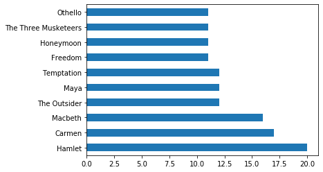

```python
top_ten.plot(kind='barh')
```

### Section II - Q1: Which years in the 2000s saw the most movies released? (Show top 3)

```python
top_three = movies.year.value_counts()[:3]
top_three
```

```
2017    11474
2016     9440
2015     8702
Name: year, dtype: int64
```

### Section II - Q2: # Plot the total number of films released per-decade (1890, 1900, 1910,....)

- Hint: Dividing the year and multiplying with a number might give you the decade the year falls into!
- You might need to sort before plotting

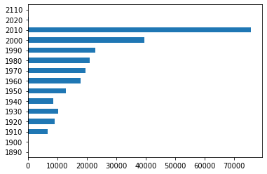

```python
decades = ((movies.year//10)*10).value_counts()
decades.sort_index().plot(kind='barh')
```

### Section II - Q3:

(A) What are the top 10 most common character names in movie history?

(B) Who are the top 10 people most often credited as "Herself" in movie history?

(C) Who are the top 10 people most often credited as "Himself" in movie history?

```python
top_char = cast.character.value_counts()[:10]
top_char
```

```
Himself        20746
Dancer         12477
Extra          11948
Reporter        8434
Student         7773
Doctor          7669
Party Guest     7245
Policeman       7029
Nurse           6999
Bartender       6802
Name: character, dtype: int64
```

```python
her = cast[cast.character == "Herself"].name.value_counts()[:10]
her
```

```
Queen Elizabeth II        12
Luisa Horga                9
Mar?a Luisa (V) Mart?n     9
Joyce Brothers             9
Hillary Clinton            8
Margaret Thatcher          8
Marilyn Monroe             6
Oprah Winfrey              6
Rekha                      6
In?s J. Southern           6
Name: name, dtype: int64
```

```python
him = cast[cast.character == "Himself"].name.value_counts()[:10]
him
```

```
Adolf Hitler          99
Richard Nixon         44
Ronald Reagan         41
John F. Kennedy       37
George W. Bush        25
Winston Churchill     24
Martin Luther King    23
Ron Jeremy            22
Bill Clinton          22
Benito Mussolini      21
Name: name, dtype: int64
```

### Section II - Q4:

(A) What are the top 10 most frequent roles that start with the word "Zombie"?

(B) What are the top 10 most frequent roles that start with the word "Police"?

- Hint: The `startswith()` function might be useful

```python
zombies = cast[cast.character.str.startswith("Zombie")].character.value_counts()[:10]
zombies
```

```
Zombie                         6264
Zombie Horde                    206
Zombie - Protestor - Victim      78
Zombie Extra                     70
Zombie Dancer                    43
Zombie Girl                      36
Zombie #1                        36
Zombie #2                        31
Zombie Vampire                   25
Zombie Victim                    22
Name: character, dtype: int64
```

```python
police = cast[cast.character.str.startswith("Police")].character.value_counts()[:10]
police
```

```
Policeman              7029
Police Officer         4808
Police Inspector        742
Police Sergeant         674
Police officer          539
Police                  456
Policewoman             415
Police Chief            410
Police Captain          387
Police Commissioner     337
Name: character, dtype: int64
```

### Section II - Q5: Plot how many roles 'Keanu Reeves' has played in each year of his career.

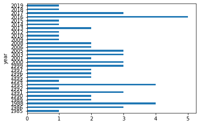

```python
keanu_df = cast[cast.name == 'Keanu Reeves']
keanu_df['character'].groupby(keanu_df.year).count().plot(kind='barh')
```

### Section II - Q6: Plot the cast positions (n-values) of Keanu Reeve's roles through his career over the years.

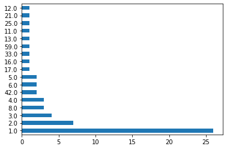

```python
keanu_df['n'].value_counts().plot(kind='barh')
```

### Section II - Q7: Plot the number of "Hamlet" films made by each decade

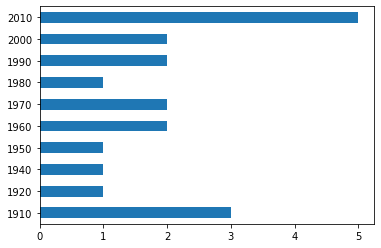

```python
hamlet = movies[movies.title == "Hamlet"]
ham_decades = ((hamlet.year//10)*10).value_counts()
ham_decades.sort_index().plot(kind='barh')
```

### Section II - Q8:

(A) How many leading roles were available to both actors and actresses, in the 1960s (1960-1969)?

(B) How many leading roles were available to both actors and actresses, in the 2000s (2000-2009)?

- Hint: A specific value of n might indicate a leading role

```python
len(cast[(cast.year >= 1960) & (cast.year <= 1969) & (cast.n == 1)])
```

```
11823
```

```python
len(cast[(cast.year >= 2000) & (cast.year <= 2009) & (cast.n == 1)])
```

```
26344
```

### Section II - Q9: List, in order by year, each of the films in which Frank Oz has played more than 1 role.

```python
frank = cast[cast.name == "Frank Oz"]
frank['title_counts'] = frank.groupby('title')['year'].transform('count')
sub = frank[frank.title_counts > 1]
sub[['title', 'year', 'title_counts']].drop_duplicates().sort_values(by=['year'], ascending=True)
```

|  | title | year | title_counts |
| --- | --- | --- | --- |
| 1723645 | The Muppet Movie | 1979 | 8 |
| 1723598 | An American Werewolf in London | 1981 | 2 |
| 1723632 | The Great Muppet Caper | 1981 | 6 |
| 1723629 | The Dark Crystal | 1982 | 2 |
| 1723653 | The Muppets Take Manhattan | 1984 | 7 |
| 1723601 | Follow That Bird | 1985 | 3 |
| 1723638 | The Muppet Christmas Carol | 1992 | 7 |
| 1723608 | Muppet Treasure Island | 1996 | 4 |
| 1723612 | Muppets from Space | 1999 | 4 |
| 1723625 | The Adventures of Elmo in Grouchland | 1999 | 3 |

### Section II - Q10: List each of the characters that Frank Oz has portrayed at least twice

```python
char_counts = frank.character.value_counts()
char_counts[char_counts > 1]
```

```
Yoda              6
Miss Piggy        6
Animal            6
Sam the Eagle     5
Cookie Monster    5
Fozzie Bear       4
Bert              3
Grover            2
Name: character, dtype: int64
```

# Section III - Advanced Merging, Querying and Visualizations

## Make a bar plot with the following conditions

- Frequency of the number of movies with "Christmas" in their title
- Movies should be such that they are released in the USA.
- Show the frequency plot by month

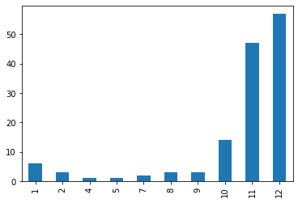

```python
christmas = release_dates[(release_dates.title.str.contains('Christmas')) & (release_dates.country == 'USA')]
christmas.date.dt.month.value_counts().sort_index().plot(kind='bar')
```

### Section III - Q1: Make a bar plot with the following conditions

- Frequency of the number of movies with "Summer" in their title
- Movies should be such that they are released in the USA.
- Show the frequency plot by month

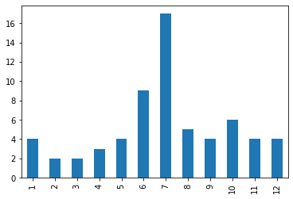

```python
summer = release_dates[(release_dates.title.str.contains('Summer')) & (release_dates.country == 'USA')]
summer.date.dt.month.value_counts().sort_index().plot(kind='bar')
```

### Section III - Q2: Make a bar plot with the following conditions

- Frequency of the number of movies with "Action" in their title
- Movies should be such that they are released in the USA.
- Show the frequency plot by week

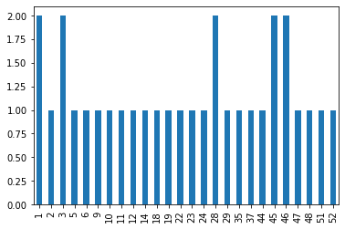

```python
action = release_dates[(release_dates.title.str.contains('Action')) & (release_dates.country == 'USA')]
action.date.dt.week.value_counts().sort_index().plot(kind='bar')
```

### Section III - Q3: Show all the movies in which Keanu Reeves has played the lead role along with their release date in the USA sorted by the date of release

- Hint: You might need to join or merge two datasets!

```python
cast_release = pd.merge(cast, release_dates, on = ['title', 'year'])
sub = cast_release[(cast_release.name == 'Keanu Reeves') & (cast_release.n == 1) & (cast_release.country == 'USA')]
sub[['title', 'date']].sort_values(by=['date'], ascending=True)
```

|  | title | date |
| --- | --- | --- |
| 16837127 | The Night Before | 1988-04-15 |
| 8395767 | Bill & Ted's Excellent Adventure | 1989-02-17 |
| 2709676 | Bill & Ted's Bogus Journey | 1991-07-19 |
| 10232894 | Little Buddha | 1994-05-25 |
| 8629940 | Speed | 1994-06-10 |
| 1803683 | Johnny Mnemonic | 1995-05-26 |
| 10458033 | A Walk in the Clouds | 1995-08-11 |
| 13350949 | Chain Reaction | 1996-08-02 |
| 14609249 | Feeling Minnesota | 1996-09-13 |
| 7805546 | The Devil's Advocate | 1997-10-17 |
| 12657786 | The Matrix | 1999-03-31 |
| 31232 | The Replacements | 2000-08-11 |
| 6070901 | Sweet November | 2001-02-16 |
| 815853 | Hard Ball | 2001-09-14 |
| 7858007 | Constantine | 2005-02-18 |
| 2270941 | The Lake House | 2006-06-16 |
| 10560879 | Street Kings | 2008-04-11 |
| 3622167 | The Day the Earth Stood Still | 2008-12-12 |
| 6320117 | 47 Ronin | 2013-12-25 |
| 2705538 | John Wick | 2014-10-24 |
| 15147049 | Knock Knock | 2015-10-09 |
| 13522810 | John Wick: Chapter 2 | 2017-02-10 |

### Section III - Q4: Make a bar plot showing the months in which movies with Keanu Reeves tend to be released in the USA?

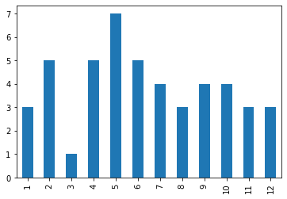

```python
keanu = cast_release[(cast_release.name == 'Keanu Reeves') & (cast_release.country == 'USA')]
keanu.date.dt.month.value_counts().sort_index().plot(kind='bar')
```

### Section III - Q5: Make a bar plot showing the years in which movies with Ian McKellen tend to be released in the USA?

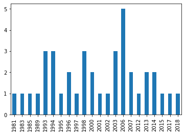

```python
ian = cast_release[(cast_release.name == 'Ian McKellen') & (cast_release.country == 'USA')]
ian.date.dt.year.value_counts().sort_index().plot(kind='bar')
```